# Fig.5

Devon DeRaad

3/18/2019

Install hzar

```r
#install.packages("hzar")
## Load the package
library(hzar)
```

Set a few parameters

```r
## A typical chain length
chainLength=1e5
## Increment skip by 15 or so for every trait
rotateModelSeeds <- function(fiComp.1)
  hzar.multiFitRequest(fiComp.1,
                       rotateSeed=TRUE, skip=500,
                       baseChannel=NULL, each=1,
                       baseSeed=c(596,528,124,978,544,99))
```

Read in the SiteLoc file, which should have two columns, one for the name of each locality (site) you chose, and a second with the distance of that site from the beginning of the cline.

```r
#bring in data
SiteLoc<-read.csv("~/Dropbox/scrub poster/manuscript/hzar.scrubbers/siteloc.csv")
head(SiteLoc)
```

```
##   Site Distance
## 1    A        0
## 2    B      100
## 3    C      300
## 4    D      430
## 5    E      640
## 6    F      760
```

Next we will read in the three data files, each with a separate variable we are hoping to model. The columns correspond to variables and the rows correspond to individuals. Site, Distance, and the variable of interest must be columns.

```r
#body size for males
malemorph<-read.csv("~/Dropbox/scrub poster/manuscript/hzar.scrubbers/malemorph.csv")
head(malemorph)
```

```
##      id Site Distance  sex       Comp.1
## 1 18334    F      760 male -2.709351277
## 2 23362    D      430 male -0.322080214
## 3 27905    D      430 male -0.744350334
## 4 27906    D      430 male -0.422455322
## 5 27907    D      430 male  0.001468766
## 6 27908    D      430 male  1.673770502
```

```r
#body size for females
femalemorph<-read.csv("~/Dropbox/scrub poster/manuscript/hzar.scrubbers/femalemorph.csv")
head(femalemorph)
```

```
##      id Site Distance    sex   Comp.1
## 1 23358    D      430 female 2.544649
## 2 23360    D      430 female 2.453736
## 3 27065    C      300 female 1.575535
## 4 27920    D      430 female 2.949411
## 5 30749    D      430 female 1.925544
## 6 32276    D      430 female 1.510762
```

```r
#blue plumage of the back for all individuals
S1blue<-read.csv("~/Dropbox/scrub poster/manuscript/hzar.scrubbers/s1.blue.csv")
head(S1blue)
```

```
##       id Site Distance   S1.blue
## 1 144750    A        0 0.3275797
## 2 144751    A        0 0.3105317
## 3 144752    A        0 0.3004815
## 4 144749    A        0 0.2811858
## 5  50598    A        0 0.3148386
## 6  57751    B      100 0.2887933
```

These all look good

Open a pdf that will eventually save the final plot. I have commented this out here, but if you uncomment it and the ‘dev.off()’ after the plot is made, it will save a PDF for you.

```r
## ## Save all plots in a pdf file?
#pdf(width=8, height=8, file="male.comp1.pdf")
```

Open lists

```r
## Blank out space in memory to hold morphological analysis
if(length(apropos("^mkn$",ignore.case=FALSE)) == 0 ||
   !is.list(mkn) ) mkn <- list()
## We are doing just the one quantitative trait, but it is
## good to stay organized.
mkn$Comp.1 <- list();
## Space to hold the observed data
mkn$Comp.1$obs <- list();
## Space to hold the models to fit
mkn$Comp.1$models <- list();
## Space to hold the compiled fit requests
mkn$Comp.1$fitRs <- list();
## Space to hold the output data chains
mkn$Comp.1$runs <- list();
## Space to hold the analysed data
mkn$Comp.1$analysis <- list()
```

This is where we set the character of interest as the focal character for the rest of the analysis.

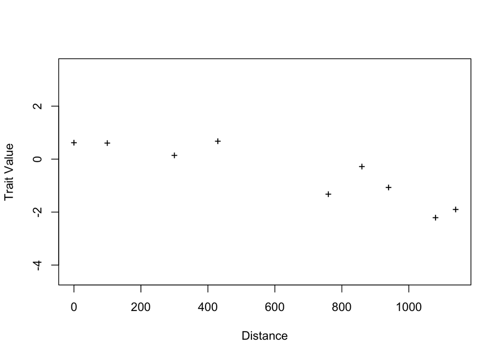

```r
## Beard Length Trait from Brumfield et al 2001
mkn$Comp.1$obs <-
  hzar.doNormalData1DRaw(hzar.mapSiteDist(SiteLoc$Site,
                                          SiteLoc$Distance),
                         malemorph$Site,
                         malemorph$Comp.1)

## Look at a graph of the observed data
hzar.plot.obsData(mkn$Comp.1$obs)
```

```r
## Make a helper function
mkn.loadComp.1model <- function(scaling,tails,
                             id=paste(scaling,tails,sep=".")){
  mkn$Comp.1$models[[id]] <<-
    hzar.makeCline1DNormal(mkn$Comp.1$obs, tails)
  ## As there is no quick option for "fixed" scaling, and the
  ## combined sites "A", "B" and "J","K" have a fair number of samples (> 20),
  ## fix the mean and variance of the left and right sides of
  ## the cline to the values observed by the combined sites.
  if (all(regexpr("fixed",scaling,ignore.case=TRUE) == 1 )){
    hzar:::meta.fix(mkn$Comp.1$models[[id]])$muL <<- TRUE
    hzar:::meta.fix(mkn$Comp.1$models[[id]])$muR <<- TRUE
    hzar:::meta.fix(mkn$Comp.1$models[[id]])$varL <<- TRUE
    hzar:::meta.fix(mkn$Comp.1$models[[id]])$varR <<- TRUE
  }
  ## Helper function to work around low sample size
  getCombo <- function(id1,id2,colName,frame=mkn$Comp.1$obs$frame)
    (frame[id1,colName]*frame[id1,"nEff"]+
       frame[id2,colName]*frame[id2,"nEff"])/
    (frame[id1,"nEff"]+frame[id2,"nEff"])

  ## Site A, B is the "left" side of the cline, so pull the
  ## fixed values from there.
  hzar:::meta.init(mkn$Comp.1$models[[id]])$muL <<-
    getCombo("A","B","mu")
  hzar:::meta.init(mkn$Comp.1$models[[id]])$varL <<-
    getCombo("A","B","var")
  ## Site J, K is the "right" side of the cline, so pull the
  ## fixed values from there.
  hzar:::meta.init(mkn$Comp.1$models[[id]])$muR <<-
    getCombo("I","J","mu")
  hzar:::meta.init(mkn$Comp.1$models[[id]])$varR <<-
    getCombo("I","J","var")
  ## Make a better estimate of varH using site D, E
  hzar:::meta.init(mkn$Comp.1$models[[id]])$varH <<-
    getCombo("E","F","var")-
    (getCombo("I","J","var")+getCombo("A","B","var"))/2

}
## mkn.loadComp.1model("fixed","none","modelI");
## mkn.loadComp.1model("free" ,"none","modelII");
## mkn.loadComp.1model("free" ,"both","modelIII");
mkn.loadComp.1model("fixed","none"  ,"fixN");
mkn.loadComp.1model("fixed","left"  ,"fixL");
mkn.loadComp.1model("fixed","right" ,"fixR");
mkn.loadComp.1model("fixed","mirror","fixM");
mkn.loadComp.1model("fixed","both"  ,"fixB");
mkn.loadComp.1model("free" ,"none"  ,"optN");
mkn.loadComp.1model("free" ,"left"  ,"opComp.1");
mkn.loadComp.1model("free" ,"right" ,"optR");
mkn.loadComp.1model("free" ,"mirror","optM");
mkn.loadComp.1model("free" ,"both"  ,"optB");


## Check the default settings
##print(mkn$Comp.1$models)

## Modify all models to focus on the region where the observed
## data were collected.
## Observations were between -10 and 130000 km.
mkn$Comp.1$models <- sapply(mkn$Comp.1$models,
                         hzar.model.addBoxReq,
                         -10 , 1100,
                         simplify=FALSE)

## Due to the large number of free variables, it is prudent to
## reduce the tune setting of optB from 1.5 to 1.1
hzar:::meta.tune(mkn$Comp.1$models$optB)<-1.1


## Check the updated settings
##print(mkn$Comp.1$models)

## Compile each of the models to prepare for fitting
## Note that we are using hzar.first.fitRequest.gC for fitting
## guassian (aka "normal") clines.
mkn$Comp.1$fitRs$init <- sapply(mkn$Comp.1$models,
                             hzar.first.fitRequest.gC,
                             obsData=mkn$Comp.1$obs,
                             verbose=TRUE,
                             simplify=FALSE)
```

[output not shown]

[output cut: 373 more lines]

```
##
## $varH
## [1] NA
##
## $deltaL
## [1] 487.5
##
## $deltaR
## [1] 487.5
##
## $tauL
## [1] 0.5
##
## $tauR
## [1] 0.5
```

```r
## Update the settings for the fitter if desired.
mkn$Comp.1$fitRs$init <- sapply(mkn$Comp.1$fitRs$init,
                             function(mdl) {
                               mdl$mcmcParam$chainLength <-
                                 chainLength; #1e5
                               mdl$mcmcParam$burnin <-
                                 chainLength %/% 10; #1e4
                               mdl },
                             simplify=FALSE)

mkn$Comp.1$fitRs$init <-
  rotateModelSeeds(mkn$Comp.1$fitRs$init)


## Check fit request settings
##print(mkn$Comp.1$fitRs$init)

## Do just one run of the models for an initial chain
mkn$Comp.1$runs$init <-
  hzar.doFit.multi(mkn$Comp.1$fitRs$init)
```

[output not shown]

[output cut: 115 more lines]

[output not shown]

```r
names(mkn$Comp.1$runs$init) <- names(mkn$Comp.1$fitRs$init)



## Compile a new set of fit requests using the initial chains
mkn$Comp.1$fitRs$chains <-
  lapply(mkn$Comp.1$runs$init,
         hzar.next.fitRequest)
```

```
## 0ac 9.2e+00dfg0ac 3.8e+05dfg0ac 5.5e+03dfg0ac 6.2e+07dfg0ac 2.5e+08dfg0ac 7.3e+04dfg0ac 4.6e+04dfg0ac 4.4e+07dfg0ac 3.3e+05dfg0ac 1.7e+03dfg
```

```r
## Replicate each fit request 3 times, keeping the original
## seeds while switching to a new seed channel.
mkn$Comp.1$fitRs$chains <-
  hzar.multiFitRequest(mkn$Comp.1$fitRs$chains,
                       each=3,
                       baseSeed=NULL)

## Just to be thorough, randomize the initial value for each fit


## Go ahead and run a chain of 3 runs for every fit request
mkn$Comp.1$runs$chains <-  hzar.doChain.multi(mkn$Comp.1$fitRs$chains,
                                           doPar=TRUE,
                                           inOrder=FALSE,
                                           count=3)
## Did fixN converge?
summary(do.call(mcmc.list,
                lapply(mkn$Comp.1$runs$chains[1:3],
                       function(x) hzar.mcmc.bindLL(x[[3]]) )) )
```

```
##
## Iterations = 10001:109901
## Thinning interval = 100
## Number of chains = 3
## Sample size per chain = 1000
##
## 1. Empirical mean and standard deviation for each variable,
##    plus standard error of the mean:
##
##            Mean      SD Naive SE Time-series SE
## center    734.8  93.836    1.713         2.9955
## width     262.4 270.472    4.938        27.9905
## varH      348.7 473.541    8.646        86.2492
## model.LL -119.3   2.191    0.040         0.1874
##
## 2. Quantiles for each variable:
##
##              2.5%     25%     50%    75%  97.5%
## center    587.107  661.60  723.49  805.7  914.3
## width       4.328   46.82  146.25  417.8  954.6
## varH        0.173    1.59   12.96  617.9 1561.8
## model.LL -124.563 -120.91 -119.42 -117.2 -116.4
```

```r
## Did optN converge?
summary(do.call(mcmc.list,
                lapply(mkn$Comp.1$runs$chains[16:18],
                       function(x) hzar.mcmc.bindLL(x[[3]]) )) )
```

```
##
## Iterations = 10001:109901
## Thinning interval = 100
## Number of chains = 3
## Sample size per chain = 1000
##
## 1. Empirical mean and standard deviation for each variable,
##    plus standard error of the mean:
##
##               Mean        SD  Naive SE Time-series SE
## center    643.7863  102.9381  1.879384      8.952e+00
## width     191.1985  266.1271  4.858794      7.575e+01
## muL         0.4888    0.3005  0.005487      1.727e-02
## muR        -1.6443    0.4554  0.008314      3.423e-02
## varL        1.9831    0.6265  0.011438      3.705e-02
## varR        2.4452    1.0639  0.019425      1.195e-01
## varH     2656.9505 4053.9654 74.014944      1.549e+03
## model.LL -117.0891    1.7044  0.031117      9.967e-02
##
## 2. Quantiles for each variable:
##
##                2.5%       25%       50%       75%      97.5%
## center    474.27004  576.1962  635.2735  695.6543   937.4360
## width       2.29124   21.0599   50.7710  319.3188   933.8590
## muL        -0.05725    0.3014    0.4821    0.6498     1.1780
## muR        -2.84638   -1.8218   -1.5849   -1.3534    -0.9509
## varL        0.99884    1.5045    1.9277    2.3773     3.4020
## varR        0.31060    1.7254    2.4423    3.1154     4.6551
## varH        0.94533    4.5368  536.6164 3362.8314 14960.3562
## model.LL -121.37455 -118.0195 -116.7651 -115.8370  -114.5708
```

```r
## Did optB converge?
summary(do.call(mcmc.list,
                lapply(mkn$Comp.1$runs$chains[28:30],
                       function(x) hzar.mcmc.bindLL(x[[3]]) )) )
```

```
##
## Iterations = 10001:109901
## Thinning interval = 100
## Number of chains = 3
## Sample size per chain = 1000
##
## 1. Empirical mean and standard deviation for each variable,
##    plus standard error of the mean:
##
##               Mean        SD  Naive SE Time-series SE
## center    617.6861   83.4339  1.523288      4.905e+00
## width      59.0409   87.6882  1.600959      1.324e+01
## muL         0.4512    0.2621  0.004785      5.622e-03
## muR        -1.5743    0.3432  0.006266      1.814e-02
## varL        1.9446    0.5744  0.010488      1.603e-02
## varR        2.6293    0.9709  0.017726      5.158e-02
## varH     1128.5303 1190.3671 21.733030      3.120e+02
## deltaL    569.7106  307.7744  5.619167      7.496e+00
## deltaR     33.8645   34.9960  0.638936      8.520e+00
## tauL        0.4977    0.2907  0.005308      7.818e-03
## tauR        0.5362    0.2751  0.005022      7.353e-03
## model.LL -116.9447    1.7170  0.031348      4.610e-02
##
## 2. Quantiles for each variable:
##
##                2.5%       25%       50%       75%     97.5%
## center    470.68426  558.1645  613.8417  670.0924  802.9845
## width       1.44545   15.3453   32.4332   57.5933  393.6026
## muL        -0.07264    0.2821    0.4489    0.6244    0.9580
## muR        -2.31897   -1.7714   -1.5636   -1.3420   -0.9367
## varL        1.08658    1.5451    1.8618    2.2467    3.3225
## varR        0.72104    2.0046    2.5731    3.2104    4.6918
## varH        2.19661  186.1155  713.1389 1851.5576 4405.7606
## deltaL     39.61052  309.1089  567.6527  828.8060 1080.4798
## deltaR      1.54432   12.7809   21.8151   40.2221  141.1010
## tauL        0.02419    0.2466    0.4971    0.7460    0.9726
## tauR        0.04743    0.3081    0.5440    0.7717    0.9814
## model.LL -121.10454 -117.8453 -116.6400 -115.7440 -114.3200
```

```r
## Start aggregation of data for analysis

## Clear out a spot to collect the data for analysis (note that
## there is currenComp.1y no "null model" to compare against).
mkn$Comp.1$analysis$initDGs <- list(
)

## Create a model data group (hzar.dataGroup object) for each
## model from the initial runs.
mkn$Comp.1$analysis$initDGs <-
  c( mkn$Comp.1$analysis$initDGs,
     sapply(mkn$Comp.1$runs$init,
            hzar.dataGroup.add,
            simplify=FALSE))

## Create a hzar.obsDataGroup object from the four hzar.dataGroup
## just created, copying the naming scheme (modelI, modelII,
## modelIII).
mkn$Comp.1$analysis$oDG <-
  hzar.make.obsDataGroup(mkn$Comp.1$analysis$initDGs)
```

```
## [1] 10
```

```r
mkn$Comp.1$analysis$oDG <-
  hzar.copyModelLabels(mkn$Comp.1$analysis$initDGs,
                       mkn$Comp.1$analysis$oDG)

## Convert all 90 runs to hzar.dataGroup objects, adding them to
## the hzar.obsDataGroup object.
mkn$Comp.1$analysis$oDG <-
  hzar.make.obsDataGroup(lapply(mkn$Comp.1$runs$chains,
                                hzar.dataGroup.add),
                         mkn$Comp.1$analysis$oDG);

## Check to make sure that there are only ten hzar.dataGroup
## objects in the hzar.obsDataGroup object.
print(summary(mkn$Comp.1$analysis$oDG$data.groups))
```

```
##          Length Class          Mode
## fixN     6      hzar.dataGroup list
## fixL     6      hzar.dataGroup list
## fixR     6      hzar.dataGroup list
## fixM     6      hzar.dataGroup list
## fixB     6      hzar.dataGroup list
## optN     6      hzar.dataGroup list
## opComp.1 6      hzar.dataGroup list
## optR     6      hzar.dataGroup list
## optM     6      hzar.dataGroup list
## optB     6      hzar.dataGroup list
```

```r
## Look at the variation in parameters for cline models
oDGkey <- which(!(names(mkn$Comp.1$analysis$oDG$data.groups) %in%
                    "nullModel"));
print(hzar.getLLCutParam(mkn$Comp.1$analysis$oDG$data.groups[oDGkey ],
                         c("center","width")));
```

```
##          center2LLLow center2LLHigh width2LLLow width2LLHigh
## fixN         570.5868      901.1119  100.146009    1108.8057
## fixL         569.5226      892.7260  100.208036    1096.3529
## fixR         550.1381      896.7296    9.677216    1108.7959
## fixM         649.4788      887.9618  125.213373     547.9921
## fixB         605.3264      850.3255   18.849927     641.9568
## optN         598.2576      916.5502    5.712156    1070.7877
## opComp.1     542.1692     1024.9068   26.420051    1109.7533
## optR         511.3978     1022.3806   22.079803    1072.4813
## optM         508.0184      803.6858    1.043989     216.7220
## optB         495.8804      834.8679    9.901211     474.5664
```

```r
## Compare the 3 cline models to the null model graphically
##hzar.plot.cline(mkn$Comp.1$analysis$oDG);

## Do model selection based on the AICc scores
print(mkn$Comp.1$analysis$AICcTable <-
        hzar.AICc.hzar.obsDataGroup(mkn$Comp.1$analysis$oDG));
```

```
##              AICc
## fixN     238.8221
## fixL     243.4606
## fixR     243.4025
## fixM     243.4594
## fixB     248.7294
## optN     241.8471
## opComp.1 247.9431
## optR     247.7580
## optM     247.8489
## optB     252.7183
```

```r
## Print out the model with the minimum AICc score
print(mkn$Comp.1$analysis$model.name <-
        rownames(mkn$Comp.1$analysis$AICcTable
        )[[ which.min(mkn$Comp.1$analysis$AICcTable$AICc )]])
```

```
## [1] "fixN"
```

```r
## Extract the hzar.dataGroup object for the selected model
mkn$Comp.1$analysis$model.selected <-
  mkn$Comp.1$analysis$oDG$data.groups[[mkn$Comp.1$analysis$model.name]]

## Plot the maximum likelihood cline for the selected model
##hzar.plot.cline(mkn$Comp.1$analysis$model.selected);

print(hzar.get.ML.cline(mkn$Comp.1$analysis$model.selected))
```

```
## $param.free
##      center    width     varH
## 29 767.5901 418.3353 1.120849
##
## $param.all
## $param.all$center
## [1] 767.5901
##
## $param.all$width
## [1] 418.3353
##
## $param.all$varH
## [1] 1.120849
##
## $param.all$muL
## [1] 0.6188497
##
## $param.all$muR
## [1] -2.080915
##
## $param.all$varL
## [1] 3.381186
##
## $param.all$varR
## [1] 1.605924
##
##
## $clineFunc
## function (x)
## 0.618849669166667 + (-2.0809150238 - 0.618849669166667) * (1/(1 +
##     exp(-4 * (x - 767.590050177515)/418.335345834094)))
##
## $logLike
## [1] -116.211
##
## $isValid
## [1] TRUE
##
## attr(,"class")
## [1] "hzar.cline"
```

check out your plot

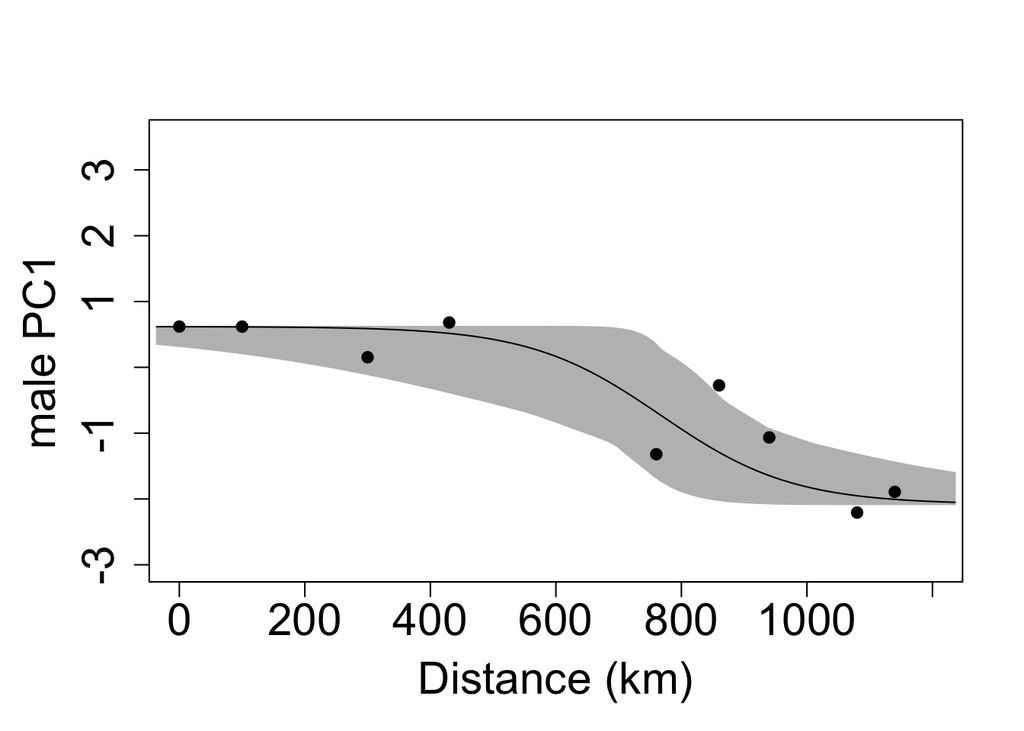

```r
## Plot the 95% credible cline region for the selected model
##hzar.plot.fzCline(mkn$Comp.1$analysis$model.selected);

par(mar=c(5,5,4,2)+.1)
par(ps=22, cex=1, cex.main=1)
male.pc1<-hzar.plot.fzCline(mkn$Comp.1$analysis$model.selected,
                  pch=19,
                  xlab="Distance (km)",
                  ylab="male PC1",
                  ylim=c(-3,3.5),xlim=c(0,1200))
```

```r
#export as 8"x8" PDF
#dev.off()
## End Comp.1
```

Open lists

```r
## Blank out space in memory to hold morphological analysis
if(length(apropos("^mkn$",ignore.case=FALSE)) == 0 ||
   !is.list(mkn) ) mkn <- list()
## We are doing just the one quantitative trait, but it is
## good to stay organized.
mkn$Comp.1 <- list();
## Space to hold the observed data
mkn$Comp.1$obs <- list();
## Space to hold the models to fit
mkn$Comp.1$models <- list();
## Space to hold the compiled fit requests
mkn$Comp.1$fitRs <- list();
## Space to hold the output data chains
mkn$Comp.1$runs <- list();
## Space to hold the analysed data
mkn$Comp.1$analysis <- list()
```

# set female body size, character 2

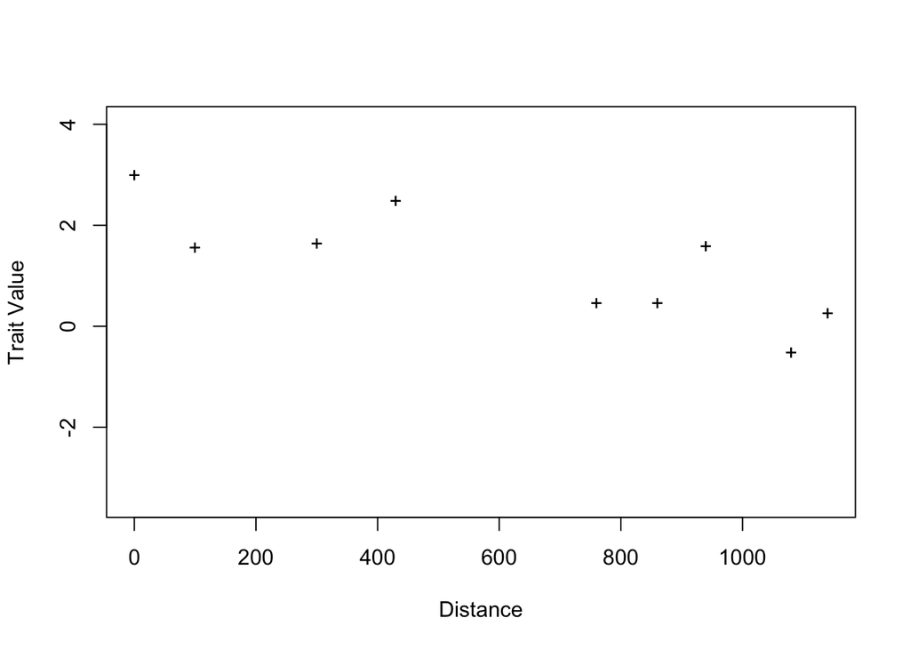

```r
## Beard Length Trait from Brumfield et al 2001
mkn$Comp.1$obs <-
  hzar.doNormalData1DRaw(hzar.mapSiteDist(SiteLoc$Site,
                                          SiteLoc$Distance),
                         femalemorph$Site,
                         femalemorph$Comp.1)

## Look at a graph of the observed data
hzar.plot.obsData(mkn$Comp.1$obs)
```

```r
## Make a helper function
mkn.loadComp.1model <- function(scaling,tails,
                             id=paste(scaling,tails,sep=".")){
  mkn$Comp.1$models[[id]] <<-
    hzar.makeCline1DNormal(mkn$Comp.1$obs, tails)
  ## As there is no quick option for "fixed" scaling, and the
  ## combined sites "A", "B" and "J","K" have a fair number of samples (> 20),
  ## fix the mean and variance of the left and right sides of
  ## the cline to the values observed by the combined sites.
  if (all(regexpr("fixed",scaling,ignore.case=TRUE) == 1 )){
    hzar:::meta.fix(mkn$Comp.1$models[[id]])$muL <<- TRUE
    hzar:::meta.fix(mkn$Comp.1$models[[id]])$muR <<- TRUE
    hzar:::meta.fix(mkn$Comp.1$models[[id]])$varL <<- TRUE
    hzar:::meta.fix(mkn$Comp.1$models[[id]])$varR <<- TRUE
  }
  ## Helper function to work around low sample size
  getCombo <- function(id1,id2,colName,frame=mkn$Comp.1$obs$frame)
    (frame[id1,colName]*frame[id1,"nEff"]+
       frame[id2,colName]*frame[id2,"nEff"])/
    (frame[id1,"nEff"]+frame[id2,"nEff"])

  ## Site A, B is the "left" side of the cline, so pull the
  ## fixed values from there.
  hzar:::meta.init(mkn$Comp.1$models[[id]])$muL <<-
    getCombo("A","B","mu")
  hzar:::meta.init(mkn$Comp.1$models[[id]])$varL <<-
    getCombo("A","B","var")
  ## Site J, K is the "right" side of the cline, so pull the
  ## fixed values from there.
  hzar:::meta.init(mkn$Comp.1$models[[id]])$muR <<-
    getCombo("I","J","mu")
  hzar:::meta.init(mkn$Comp.1$models[[id]])$varR <<-
    getCombo("I","J","var")
  ## Make a better estimate of varH using site D, E
  hzar:::meta.init(mkn$Comp.1$models[[id]])$varH <<-
    getCombo("E","F","var")-
    (getCombo("I","J","var")+getCombo("A","B","var"))/2

}
## mkn.loadComp.1model("fixed","none","modelI");
## mkn.loadComp.1model("free" ,"none","modelII");
## mkn.loadComp.1model("free" ,"both","modelIII");
mkn.loadComp.1model("fixed","none"  ,"fixN");
mkn.loadComp.1model("fixed","left"  ,"fixL");
mkn.loadComp.1model("fixed","right" ,"fixR");
mkn.loadComp.1model("fixed","mirror","fixM");
mkn.loadComp.1model("fixed","both"  ,"fixB");
mkn.loadComp.1model("free" ,"none"  ,"optN");
mkn.loadComp.1model("free" ,"left"  ,"opComp.1");
mkn.loadComp.1model("free" ,"right" ,"optR");
mkn.loadComp.1model("free" ,"mirror","optM");
mkn.loadComp.1model("free" ,"both"  ,"optB");


## Check the default settings
##print(mkn$Comp.1$models)

## Modify all models to focus on the region where the observed
## data were collected.
## Observations were between -10 and 130000 km.
mkn$Comp.1$models <- sapply(mkn$Comp.1$models,
                         hzar.model.addBoxReq,
                         -10 , 1100,
                         simplify=FALSE)

## Due to the large number of free variables, it is prudent to
## reduce the tune setting of optB from 1.5 to 1.1
hzar:::meta.tune(mkn$Comp.1$models$optB)<-1.1


## Check the updated settings
##print(mkn$Comp.1$models)

## Compile each of the models to prepare for fitting
## Note that we are using hzar.first.fitRequest.gC for fitting
## guassian (aka "normal") clines.
mkn$Comp.1$fitRs$init <- sapply(mkn$Comp.1$models,
                             hzar.first.fitRequest.gC,
                             obsData=mkn$Comp.1$obs,
                             verbose=TRUE,
                             simplify=FALSE)
```

[output not shown]

[output cut: 373 more lines]

```
##
## $varH
## [1] NA
##
## $deltaL
## [1] 247.5
##
## $deltaR
## [1] 247.5
##
## $tauL
## [1] 0.5
##
## $tauR
## [1] 0.5
```

```r
## Update the settings for the fitter if desired.
mkn$Comp.1$fitRs$init <- sapply(mkn$Comp.1$fitRs$init,
                             function(mdl) {
                               mdl$mcmcParam$chainLength <-
                                 chainLength; #1e5
                               mdl$mcmcParam$burnin <-
                                 chainLength %/% 10; #1e4
                               mdl },
                             simplify=FALSE)

mkn$Comp.1$fitRs$init <-
  rotateModelSeeds(mkn$Comp.1$fitRs$init)


## Check fit request settings
##print(mkn$Comp.1$fitRs$init)

## Do just one run of the models for an initial chain
mkn$Comp.1$runs$init <-
  hzar.doFit.multi(mkn$Comp.1$fitRs$init)
```

[output not shown]

[output cut: 115 more lines]

[output not shown]

```r
names(mkn$Comp.1$runs$init) <- names(mkn$Comp.1$fitRs$init)



## Compile a new set of fit requests using the initial chains
mkn$Comp.1$fitRs$chains <-
  lapply(mkn$Comp.1$runs$init,
         hzar.next.fitRequest)
```

```
## 0ac 1.3e+05dfg0ac 4.8e+07dfg0ac 5.3e+06dfg0ac 8.5e+07dfg0ac 2.0e+11dfg0ac 8.7e+06dfg0ac 3.3e+09dfg0ac 1.1e+06dfg0ac 3.2e+05dfg0ac 9.5e+02dfg
```

```r
## Replicate each fit request 3 times, keeping the original
## seeds while switching to a new seed channel.
mkn$Comp.1$fitRs$chains <-
  hzar.multiFitRequest(mkn$Comp.1$fitRs$chains,
                       each=3,
                       baseSeed=NULL)

## Just to be thorough, randomize the initial value for each fit


## Go ahead and run a chain of 3 runs for every fit request
mkn$Comp.1$runs$chains <-  hzar.doChain.multi(mkn$Comp.1$fitRs$chains,
                                           doPar=TRUE,
                                           inOrder=FALSE,
                                           count=3)
```

```r
## Did fixN converge?
summary(do.call(mcmc.list,
                lapply(mkn$Comp.1$runs$chains[1:3],
                       function(x) hzar.mcmc.bindLL(x[[3]]) )) )
```

```
##
## Iterations = 10001:109901
## Thinning interval = 100
## Number of chains = 3
## Sample size per chain = 1000
##
## 1. Empirical mean and standard deviation for each variable,
##    plus standard error of the mean:
##
##                Mean        SD  Naive SE Time-series SE
## center    5.952e+02 6.722e+01 1.227e+00      1.305e+00
## width     9.006e+00 6.417e+00 1.172e-01      1.158e-01
## varH      1.988e+10 2.261e+10 4.128e+08      7.096e+09
## model.LL -6.639e+01 2.379e-01 4.344e-03      4.344e-03
##
## 2. Quantiles for each variable:
##
##                2.5%        25%        50%        75%      97.5%
## center    4.681e+02  5.458e+02  5.948e+02  6.444e+02  7.222e+02
## width     3.231e-01  3.665e+00  7.843e+00  1.342e+01  2.306e+01
## varH      4.601e+08  4.177e+09  1.128e+10  2.533e+10  8.060e+10
## model.LL -6.684e+01 -6.635e+01 -6.635e+01 -6.635e+01 -6.634e+01
```

```r
## Did optN converge?
summary(do.call(mcmc.list,
                lapply(mkn$Comp.1$runs$chains[16:18],
                       function(x) hzar.mcmc.bindLL(x[[3]]) )) )
```

```
##
## Iterations = 10001:109901
## Thinning interval = 100
## Number of chains = 3
## Sample size per chain = 1000
##
## 1. Empirical mean and standard deviation for each variable,
##    plus standard error of the mean:
##
##                Mean        SD  Naive SE Time-series SE
## center    5.949e+02 7.356e+01 1.343e+00      1.793e+00
## width     1.318e+01 9.576e+00 1.748e-01      2.006e-01
## muL       2.083e+00 2.279e-01 4.161e-03      5.016e-03
## muR       1.966e-01 3.100e-01 5.660e-03      5.969e-03
## varL      9.055e-01 4.193e-01 7.655e-03      9.383e-03
## varR      2.310e+00 7.740e-01 1.413e-02      1.549e-02
## varH      6.760e+06 6.855e+06 1.251e+05      1.896e+06
## model.LL -6.587e+01 1.827e+00 3.335e-02      4.188e-02
##
## 2. Quantiles for each variable:
##
##                2.5%        25%        50%        75%      97.5%
## center    4.647e+02  5.446e+02  5.936e+02  6.427e+02  7.282e+02
## width     5.844e-01  5.155e+00  1.142e+01  1.946e+01  3.433e+01
## muL       1.626e+00  1.937e+00  2.080e+00  2.233e+00  2.518e+00
## muR      -4.393e-01  8.607e-06  2.036e-01  3.936e-01  8.101e-01
## varL      4.042e-01  6.327e-01  8.108e-01  1.072e+00  1.974e+00
## varR      1.256e+00  1.763e+00  2.167e+00  2.691e+00  4.204e+00
## varH      1.980e+05  1.779e+06  5.035e+06  7.493e+06  2.536e+07
## model.LL -7.055e+01 -6.678e+01 -6.546e+01 -6.452e+01 -6.364e+01
```

```r
## Did optB converge?
summary(do.call(mcmc.list,
                lapply(mkn$Comp.1$runs$chains[28:30],
                       function(x) hzar.mcmc.bindLL(x[[3]]) )) )
```

```
##
## Iterations = 10001:109901
## Thinning interval = 100
## Number of chains = 3
## Sample size per chain = 1000
##
## 1. Empirical mean and standard deviation for each variable,
##    plus standard error of the mean:
##
##                Mean        SD  Naive SE Time-series SE
## center     469.2421 2.372e+02 4.330e+00      4.959e+01
## width       18.4759 1.524e+01 2.782e-01      1.971e+00
## muL          1.7060 7.727e+00 1.411e-01      6.682e-01
## muR          0.4619 4.756e-01 8.683e-03      1.916e-02
## varL        48.2723 1.226e+02 2.238e+00      1.529e+01
## varR         2.2810 6.452e-01 1.178e-02      2.067e-02
## varH     55698.7891 5.035e+04 9.192e+02      1.732e+04
## deltaL     568.1991 3.062e+02 5.591e+00      1.769e+01
## deltaR     593.4547 3.205e+02 5.851e+00      1.959e+01
## tauL         0.5143 2.750e-01 5.021e-03      1.240e-02
## tauR         0.3698 3.329e-01 6.077e-03      2.086e-02
## model.LL   -69.6269 5.863e+00 1.071e-01      4.923e-01
##
## 2. Quantiles for each variable:
##
##                2.5%        25%        50%        75%      97.5%
## center     -6.77728  468.34131   576.4771  6.192e+02  7.137e+02
## width       0.29211    5.13827    14.4484  2.914e+01  4.677e+01
## muL       -28.10861    1.88481     2.1154  2.314e+00  2.031e+01
## muR        -0.34595    0.10504     0.3879  7.931e-01  1.252e+00
## varL        0.42425    0.72260     1.0699  1.951e+00  4.631e+02
## varR        1.29718    1.87227     2.2344  2.551e+00  3.934e+00
## varH     1110.02400 9918.77420 39505.8889  1.020e+05  1.497e+05
## deltaL     48.39311  315.15706   529.9740  8.263e+02  1.082e+03
## deltaR     36.89591  298.91913   619.5695  8.980e+02  1.076e+03
## tauL        0.03555    0.27401     0.5456  7.129e-01  9.690e-01
## tauR        0.00521    0.03221     0.3098  6.608e-01  9.676e-01
## model.LL  -81.82404  -72.09974   -66.7813 -6.499e+01 -6.372e+01
```

```r
## Start aggregation of data for analysis

## Clear out a spot to collect the data for analysis (note that
## there is currenComp.1y no "null model" to compare against).
mkn$Comp.1$analysis$initDGs <- list(
)

## Create a model data group (hzar.dataGroup object) for each
## model from the initial runs.
mkn$Comp.1$analysis$initDGs <-
  c( mkn$Comp.1$analysis$initDGs,
     sapply(mkn$Comp.1$runs$init,
            hzar.dataGroup.add,
            simplify=FALSE))

## Create a hzar.obsDataGroup object from the four hzar.dataGroup
## just created, copying the naming scheme (modelI, modelII,
## modelIII).
mkn$Comp.1$analysis$oDG <-
  hzar.make.obsDataGroup(mkn$Comp.1$analysis$initDGs)
```

```
## [1] 10
```

```r
mkn$Comp.1$analysis$oDG <-
  hzar.copyModelLabels(mkn$Comp.1$analysis$initDGs,
                       mkn$Comp.1$analysis$oDG)

## Convert all 90 runs to hzar.dataGroup objects, adding them to
## the hzar.obsDataGroup object.
mkn$Comp.1$analysis$oDG <-
  hzar.make.obsDataGroup(lapply(mkn$Comp.1$runs$chains,
                                hzar.dataGroup.add),
                         mkn$Comp.1$analysis$oDG);

## Check to make sure that there are only ten hzar.dataGroup
## objects in the hzar.obsDataGroup object.
print(summary(mkn$Comp.1$analysis$oDG$data.groups))
```

```
##          Length Class          Mode
## fixN     6      hzar.dataGroup list
## fixL     6      hzar.dataGroup list
## fixR     6      hzar.dataGroup list
## fixM     6      hzar.dataGroup list
## fixB     6      hzar.dataGroup list
## optN     6      hzar.dataGroup list
## opComp.1 6      hzar.dataGroup list
## optR     6      hzar.dataGroup list
## optM     6      hzar.dataGroup list
## optB     6      hzar.dataGroup list
```

```r
## Look at the variation in parameters for cline models
oDGkey <- which(!(names(mkn$Comp.1$analysis$oDG$data.groups) %in%
                    "nullModel"));
print(hzar.getLLCutParam(mkn$Comp.1$analysis$oDG$data.groups[oDGkey ],
                         c("center","width")));
```

```
##          center2LLLow center2LLHigh  width2LLLow width2LLHigh
## fixN         431.8573      758.5822 3.631575e-04    175.34583
## fixL         646.1532      857.7134 2.130413e+02   1027.58223
## fixR         629.9611      892.1097 2.147997e+02   1104.31787
## fixM         631.8532      849.0595 2.967024e+02    817.44244
## fixB         432.9208      757.1477 3.171246e-03     52.45349
## optN         432.9159      755.7764 5.894040e-03    131.25418
## opComp.1     434.6536     1030.5399 2.703715e-02   1060.11295
## optR         486.4270     1099.8703 2.806538e+00   1108.86277
## optM         433.1334     1093.2362 3.715158e-03    670.02624
## optB         438.4038      758.8468 4.680506e-02    271.22222
```

```r
## Compare the 3 cline models to the null model graphically
##hzar.plot.cline(mkn$Comp.1$analysis$oDG);

## Do model selection based on the AICc scores
print(mkn$Comp.1$analysis$AICcTable <-
        hzar.AICc.hzar.obsDataGroup(mkn$Comp.1$analysis$oDG));
```

```
##              AICc
## fixN     137.6580
## fixL     136.5327
## fixR     136.9571
## fixM     137.0759
## fixB     149.6559
## optN     143.8963
## opComp.1 150.3607
## optR     149.0548
## optM     149.6581
## optB     157.4560
```

```r
## Print out the model with the minimum AICc score
print(mkn$Comp.1$analysis$model.name <-
        rownames(mkn$Comp.1$analysis$AICcTable
        )[[ which.min(mkn$Comp.1$analysis$AICcTable$AICc )]])
```

```
## [1] "fixL"
```

```r
## Extract the hzar.dataGroup object for the selected model
mkn$Comp.1$analysis$model.selected <-
  mkn$Comp.1$analysis$oDG$data.groups[[mkn$Comp.1$analysis$model.name]]

## Plot the maximum likelihood cline for the selected model
##hzar.plot.cline(mkn$Comp.1$analysis$model.selected);

print(hzar.get.ML.cline(mkn$Comp.1$analysis$model.selected))
```

```
## $param.free
##       center    width      varH   deltaL      tauL
## 268 738.3201 584.5537 0.2391903 294.5393 0.2901645
##
## $param.all
## $param.all$center
## [1] 738.3201
##
## $param.all$width
## [1] 584.5537
##
## $param.all$varH
## [1] 0.2391903
##
## $param.all$deltaL
## [1] 294.5393
##
## $param.all$tauL
## [1] 0.2901645
##
## $param.all$muL
## [1] 2.282268
##
## $param.all$muR
## [1] -0.3916515
##
## $param.all$varL
## [1] 0.515512
##
## $param.all$varR
## [1] 1.900138
##
##
## $clineFunc
## function (x)
## ifelse(x < 738.320054580216 - 294.539327280036, 2.2822678625 +
##     (-0.391651469083333 - 2.2822678625) * (exp(4 * 294.539327280036/584.553726915779 *
##         (0.290164525249832 - 1))/(1 + exp(-(4 * 294.539327280036/584.553726915779))) *
##         exp(4 * (x - 738.320054580216)/584.553726915779 * 0.290164525249832)),
##     2.2822678625 + (-0.391651469083333 - 2.2822678625) * (1/(1 +
##         exp(-4 * (x - 738.320054580216)/584.553726915779))))
##
## $logLike
## [1] -62.43304
##
## $isValid
## [1] TRUE
##
## attr(,"class")
## [1] "hzar.cline"
```

check out your plot

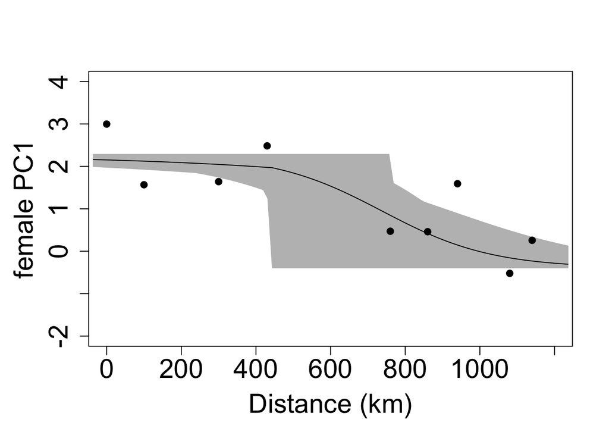

```r
## Plot the 95% credible cline region for the selected model
##hzar.plot.fzCline(mkn$Comp.1$analysis$model.selected);

par(mar=c(5,5,4,2)+.1)
par(ps=22, cex=1, cex.main=1)
male.pc1<-hzar.plot.fzCline(mkn$Comp.1$analysis$model.selected,
                  pch=19,
                  xlab="Distance (km)",
                  ylab="female PC1",
                  ylim=c(-2,4),xlim=c(0,1200))
```

```r
#export as 8"x8" PDF
#dev.off()
## End Comp.1
```

Open lists

```r
## Blank out space in memory to hold morphological analysis
if(length(apropos("^mkn$",ignore.case=FALSE)) == 0 ||
   !is.list(mkn) ) mkn <- list()
## We are doing just the one quantitative trait, but it is
## good to stay organized.
mkn$Comp.1 <- list();
## Space to hold the observed data
mkn$Comp.1$obs <- list();
## Space to hold the models to fit
mkn$Comp.1$models <- list();
## Space to hold the compiled fit requests
mkn$Comp.1$fitRs <- list();
## Space to hold the output data chains
mkn$Comp.1$runs <- list();
## Space to hold the analysed data
mkn$Comp.1$analysis <- list()
```

# Set s1blue, character 3

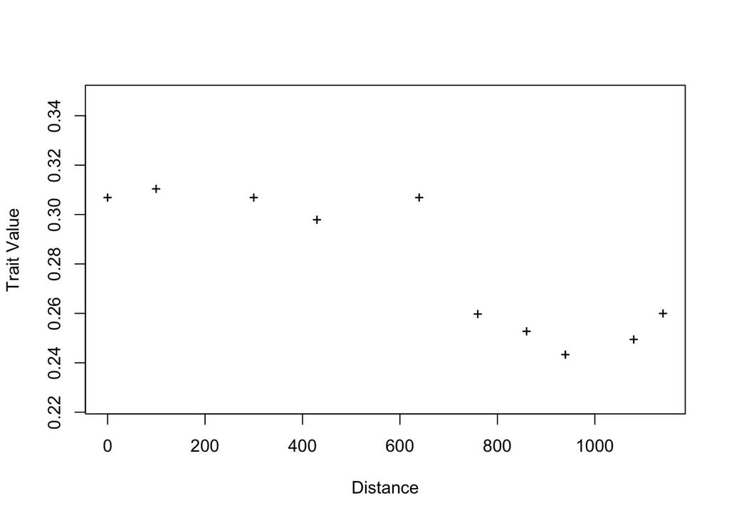

```r
## Beard Length Trait from Brumfield et al 2001
mkn$Comp.1$obs <-
  hzar.doNormalData1DRaw(hzar.mapSiteDist(SiteLoc$Site,
                                          SiteLoc$Distance),
                         S1blue$Site,
                         S1blue$S1.blue)

## Look at a graph of the observed data
hzar.plot.obsData(mkn$Comp.1$obs)
```

```r
## Make a helper function
mkn.loadComp.1model <- function(scaling,tails,
                             id=paste(scaling,tails,sep=".")){
  mkn$Comp.1$models[[id]] <<-
    hzar.makeCline1DNormal(mkn$Comp.1$obs, tails)
  ## As there is no quick option for "fixed" scaling, and the
  ## combined sites "A", "B" and "J","K" have a fair number of samples (> 20),
  ## fix the mean and variance of the left and right sides of
  ## the cline to the values observed by the combined sites.
  if (all(regexpr("fixed",scaling,ignore.case=TRUE) == 1 )){
    hzar:::meta.fix(mkn$Comp.1$models[[id]])$muL <<- TRUE
    hzar:::meta.fix(mkn$Comp.1$models[[id]])$muR <<- TRUE
    hzar:::meta.fix(mkn$Comp.1$models[[id]])$varL <<- TRUE
    hzar:::meta.fix(mkn$Comp.1$models[[id]])$varR <<- TRUE
  }
  ## Helper function to work around low sample size
  getCombo <- function(id1,id2,colName,frame=mkn$Comp.1$obs$frame)
    (frame[id1,colName]*frame[id1,"nEff"]+
       frame[id2,colName]*frame[id2,"nEff"])/
    (frame[id1,"nEff"]+frame[id2,"nEff"])

  ## Site A, B is the "left" side of the cline, so pull the
  ## fixed values from there.
  hzar:::meta.init(mkn$Comp.1$models[[id]])$muL <<-
    getCombo("A","B","mu")
  hzar:::meta.init(mkn$Comp.1$models[[id]])$varL <<-
    getCombo("A","B","var")
  ## Site J, K is the "right" side of the cline, so pull the
  ## fixed values from there.
  hzar:::meta.init(mkn$Comp.1$models[[id]])$muR <<-
    getCombo("I","J","mu")
  hzar:::meta.init(mkn$Comp.1$models[[id]])$varR <<-
    getCombo("I","J","var")
  ## Make a better estimate of varH using site D, E
  hzar:::meta.init(mkn$Comp.1$models[[id]])$varH <<-
    getCombo("E","F","var")-
    (getCombo("I","J","var")+getCombo("A","B","var"))/2

}
## mkn.loadComp.1model("fixed","none","modelI");
## mkn.loadComp.1model("free" ,"none","modelII");
## mkn.loadComp.1model("free" ,"both","modelIII");
mkn.loadComp.1model("fixed","none"  ,"fixN");
mkn.loadComp.1model("fixed","left"  ,"fixL");
mkn.loadComp.1model("fixed","right" ,"fixR");
mkn.loadComp.1model("fixed","mirror","fixM");
mkn.loadComp.1model("fixed","both"  ,"fixB");
mkn.loadComp.1model("free" ,"none"  ,"optN");
mkn.loadComp.1model("free" ,"left"  ,"opComp.1");
mkn.loadComp.1model("free" ,"right" ,"optR");
mkn.loadComp.1model("free" ,"mirror","optM");
mkn.loadComp.1model("free" ,"both"  ,"optB");


## Check the default settings
##print(mkn$Comp.1$models)

## Modify all models to focus on the region where the observed
## data were collected.
## Observations were between -10 and 130000 km.
mkn$Comp.1$models <- sapply(mkn$Comp.1$models,
                         hzar.model.addBoxReq,
                         -10 , 1100,
                         simplify=FALSE)

## Due to the large number of free variables, it is prudent to
## reduce the tune setting of optB from 1.5 to 1.1
hzar:::meta.tune(mkn$Comp.1$models$optB)<-1.1


## Check the updated settings
##print(mkn$Comp.1$models)

## Compile each of the models to prepare for fitting
## Note that we are using hzar.first.fitRequest.gC for fitting
## guassian (aka "normal") clines.
mkn$Comp.1$fitRs$init <- sapply(mkn$Comp.1$models,
                             hzar.first.fitRequest.gC,
                             obsData=mkn$Comp.1$obs,
                             verbose=TRUE,
                             simplify=FALSE)
```

```
## a
## ab
## a
## a
## ab
## a
## ab
## a
## a
## ab
```

```r
## Update the settings for the fitter if desired.
mkn$Comp.1$fitRs$init <- sapply(mkn$Comp.1$fitRs$init,
                             function(mdl) {
                               mdl$mcmcParam$chainLength <-
                                 chainLength; #1e5
                               mdl$mcmcParam$burnin <-
                                 chainLength %/% 10; #1e4
                               mdl },
                             simplify=FALSE)

mkn$Comp.1$fitRs$init <-
  rotateModelSeeds(mkn$Comp.1$fitRs$init)


## Check fit request settings
##print(mkn$Comp.1$fitRs$init)

## Do just one run of the models for an initial chain
mkn$Comp.1$runs$init <-
  hzar.doFit.multi(mkn$Comp.1$fitRs$init)
```

[output not shown]

[output cut: 115 more lines]

[output not shown]

```r
names(mkn$Comp.1$runs$init) <- names(mkn$Comp.1$fitRs$init)



## Compile a new set of fit requests using the initial chains
mkn$Comp.1$fitRs$chains <-
  lapply(mkn$Comp.1$runs$init,
         hzar.next.fitRequest)
```

```
## 0ac 3.0e+01dfg0ac 3.4e+01dfg0ac 3.1e+04dfg0ac 2.3e-13dfg0ac 4.0e-10dfg0ac 1.5e-10dfg0ac 1.0e-10dfg0ac 1.2e-06dfg
```

```r
## Replicate each fit request 3 times, keeping the original
## seeds while switching to a new seed channel.
mkn$Comp.1$fitRs$chains <-
  hzar.multiFitRequest(mkn$Comp.1$fitRs$chains,
                       each=3,
                       baseSeed=NULL)

## Just to be thorough, randomize the initial value for each fit


## Go ahead and run a chain of 3 runs for every fit request
mkn$Comp.1$runs$chains <-  hzar.doChain.multi(mkn$Comp.1$fitRs$chains,
                                           doPar=TRUE,
                                           inOrder=FALSE,
                                           count=3)
```

```r
## Did fixN converge?
summary(do.call(mcmc.list,
                lapply(mkn$Comp.1$runs$chains[1:3],
                       function(x) hzar.mcmc.bindLL(x[[3]]) )) )
```

```
##
## Iterations = 10001:109901
## Thinning interval = 100
## Number of chains = 3
## Sample size per chain = 1000
##
## 1. Empirical mean and standard deviation for each variable,
##    plus standard error of the mean:
##
##               Mean        SD Naive SE Time-series SE
## center   671.66676  43.46084 0.793483       2.334592
## width    186.22240 116.07748 2.119275       7.961357
## varH       0.02785   0.08392 0.001532       0.009158
## model.LL 291.55093   1.42103 0.025944       0.061556
##
## 2. Quantiles for each variable:
##
##               2.5%       25%       50%       75%    97.5%
## center   5.934e+02 6.357e+02 672.64406 7.087e+02 745.0107
## width    1.238e+01 7.796e+01 191.61099 2.744e+02 410.5853
## varH     2.893e-04 6.051e-04   0.00108 4.273e-03   0.2959
## model.LL 2.879e+02 2.909e+02 291.65888 2.926e+02 293.3178
```

```r
## Did optN converge?
summary(do.call(mcmc.list,
                lapply(mkn$Comp.1$runs$chains[16:18],
                       function(x) hzar.mcmc.bindLL(x[[3]]) )) )
```

```
##
## Iterations = 10001:109901
## Thinning interval = 100
## Number of chains = 3
## Sample size per chain = 1000
##
## 1. Empirical mean and standard deviation for each variable,
##    plus standard error of the mean:
##
##               Mean        SD  Naive SE Time-series SE
## center   6.999e+02 3.684e+01 6.725e-01      2.159e+00
## width    8.988e+01 1.019e+02 1.860e+00      1.153e+01
## muL      3.044e-01 2.946e-03 5.378e-05      1.344e-04
## muR      2.511e-01 1.990e-03 3.633e-05      9.471e-05
## varL     3.306e-04 7.451e-05 1.360e-06      3.726e-06
## varR     1.753e-04 4.804e-05 8.771e-07      2.538e-06
## varH     7.101e-02 1.223e-01 2.232e-03      2.926e-02
## model.LL 2.927e+02 2.260e+00 4.126e-02      1.457e-01
##
## 2. Quantiles for each variable:
##
##               2.5%       25%       50%       75%     97.5%
## center   6.112e+02 6.855e+02 7.090e+02 7.243e+02 7.517e+02
## width    4.241e+00 2.438e+01 3.902e+01 1.248e+02 3.807e+02
## muL      2.987e-01 3.024e-01 3.042e-01 3.062e-01 3.105e-01
## muR      2.472e-01 2.499e-01 2.512e-01 2.524e-01 2.552e-01
## varL     2.140e-04 2.755e-04 3.209e-04 3.679e-04 5.095e-04
## varR     1.057e-04 1.422e-04 1.689e-04 1.988e-04 2.899e-04
## varH     2.638e-04 8.062e-04 1.365e-02 8.380e-02 4.756e-01
## model.LL 2.873e+02 2.914e+02 2.932e+02 2.945e+02 2.963e+02
```

```r
## Did optB converge?
summary(do.call(mcmc.list,
                lapply(mkn$Comp.1$runs$chains[28:30],
                       function(x) hzar.mcmc.bindLL(x[[3]]) )) )
```

```
##
## Iterations = 10001:109901
## Thinning interval = 100
## Number of chains = 3
## Sample size per chain = 1000
##
## 1. Empirical mean and standard deviation for each variable,
##    plus standard error of the mean:
##
##               Mean        SD  Naive SE Time-series SE
## center   7.008e+02 3.532e+01 6.449e-01      1.973e+00
## width    1.026e+02 9.531e+01 1.740e+00      8.562e+00
## muL      3.044e-01 2.755e-03 5.029e-05      1.479e-04
## muR      2.510e-01 2.083e-03 3.803e-05      1.050e-04
## varL     3.329e-04 8.283e-05 1.512e-06      4.757e-06
## varR     1.689e-04 4.496e-05 8.208e-07      2.198e-06
## varH     2.489e-02 4.461e-02 8.144e-04      1.252e-02
## deltaL   5.926e+02 3.264e+02 5.960e+00      1.787e+01
## deltaR   5.564e+02 3.164e+02 5.778e+00      1.647e+01
## tauL     5.219e-01 2.922e-01 5.334e-03      1.519e-02
## tauR     5.287e-01 2.959e-01 5.402e-03      1.537e-02
## model.LL 2.928e+02 2.199e+00 4.015e-02      1.318e-01
##
## 2. Quantiles for each variable:
##
##               2.5%       25%       50%       75%     97.5%
## center   6.128e+02 6.840e+02 7.082e+02 7.247e+02 7.521e+02
## width    7.787e+00 2.935e+01 5.861e+01 1.628e+02 3.418e+02
## muL      2.993e-01 3.026e-01 3.044e-01 3.064e-01 3.097e-01
## muR      2.466e-01 2.497e-01 2.511e-01 2.524e-01 2.549e-01
## varL     2.063e-04 2.771e-04 3.220e-04 3.732e-04 5.381e-04
## varR     1.004e-04 1.398e-04 1.618e-04 1.906e-04 2.795e-04
## varH     1.866e-04 7.458e-04 3.285e-03 2.823e-02 1.965e-01
## deltaL   3.938e+01 3.101e+02 6.135e+02 8.906e+02 1.086e+03
## deltaR   2.762e+01 2.941e+02 5.614e+02 8.246e+02 1.082e+03
## tauL     2.395e-02 2.731e-01 5.232e-01 7.761e-01 9.708e-01
## tauR     2.747e-02 2.743e-01 5.521e-01 8.007e-01 9.757e-01
## model.LL 2.874e+02 2.917e+02 2.932e+02 2.944e+02 2.958e+02
```

```r
## Start aggregation of data for analysis

## Clear out a spot to collect the data for analysis (note that
## there is currenComp.1y no "null model" to compare against).
mkn$Comp.1$analysis$initDGs <- list(
)

## Create a model data group (hzar.dataGroup object) for each
## model from the initial runs.
mkn$Comp.1$analysis$initDGs <-
  c( mkn$Comp.1$analysis$initDGs,
     sapply(mkn$Comp.1$runs$init,
            hzar.dataGroup.add,
            simplify=FALSE))

## Create a hzar.obsDataGroup object from the four hzar.dataGroup
## just created, copying the naming scheme (modelI, modelII,
## modelIII).
mkn$Comp.1$analysis$oDG <-
  hzar.make.obsDataGroup(mkn$Comp.1$analysis$initDGs)
```

```
## [1] 10
```

```r
mkn$Comp.1$analysis$oDG <-
  hzar.copyModelLabels(mkn$Comp.1$analysis$initDGs,
                       mkn$Comp.1$analysis$oDG)

## Convert all 90 runs to hzar.dataGroup objects, adding them to
## the hzar.obsDataGroup object.
mkn$Comp.1$analysis$oDG <-
  hzar.make.obsDataGroup(lapply(mkn$Comp.1$runs$chains,
                                hzar.dataGroup.add),
                         mkn$Comp.1$analysis$oDG);

## Check to make sure that there are only ten hzar.dataGroup
## objects in the hzar.obsDataGroup object.
print(summary(mkn$Comp.1$analysis$oDG$data.groups))
```

```
##          Length Class          Mode
## fixN     6      hzar.dataGroup list
## fixL     6      hzar.dataGroup list
## fixR     6      hzar.dataGroup list
## fixM     6      hzar.dataGroup list
## fixB     6      hzar.dataGroup list
## optN     6      hzar.dataGroup list
## opComp.1 6      hzar.dataGroup list
## optR     6      hzar.dataGroup list
## optM     6      hzar.dataGroup list
## optB     6      hzar.dataGroup list
```

```r
## Look at the variation in parameters for cline models
oDGkey <- which(!(names(mkn$Comp.1$analysis$oDG$data.groups) %in%
                    "nullModel"));
print(hzar.getLLCutParam(mkn$Comp.1$analysis$oDG$data.groups[oDGkey ],
                         c("center","width")));
```

```
##          center2LLLow center2LLHigh width2LLLow width2LLHigh
## fixN         578.3736      758.1562    1.803656     443.4818
## fixL         580.9194      756.9412    5.367603     432.3465
## fixR         597.7917      742.3926   24.470445     390.2488
## fixM         596.0455      743.9821    6.625518     404.4922
## fixB         591.8088      743.5797   29.608225     396.1837
## optN         625.4291      755.8415    4.242026     350.4086
## opComp.1     635.4487      757.7666    4.915279     337.1956
## optR         631.2074      755.7073    7.056708     301.2841
## optM         629.2808      757.3022    5.279546     346.3259
## optB         623.9532      759.4977    1.470854     330.7832
```

```r
## Compare the 3 cline models to the null model graphically
##hzar.plot.cline(mkn$Comp.1$analysis$oDG);

## Do model selection based on the AICc scores
print(mkn$Comp.1$analysis$AICcTable <-
        hzar.AICc.hzar.obsDataGroup(mkn$Comp.1$analysis$oDG));
```

```
##               AICc
## fixN     -580.7700
## fixL     -576.8672
## fixR     -578.5012
## fixM     -578.1614
## fixB     -573.6726
## optN     -578.5923
## opComp.1 -573.8543
## optR     -574.0469
## optM     -573.8801
## optB     -569.2569
```

```r
## Print out the model with the minimum AICc score
print(mkn$Comp.1$analysis$model.name <-
        rownames(mkn$Comp.1$analysis$AICcTable
        )[[ which.min(mkn$Comp.1$analysis$AICcTable$AICc )]])
```

```
## [1] "fixN"
```

```r
## Extract the hzar.dataGroup object for the selected model
mkn$Comp.1$analysis$model.selected <-
  mkn$Comp.1$analysis$oDG$data.groups[[mkn$Comp.1$analysis$model.name]]

## Plot the maximum likelihood cline for the selected model
##hzar.plot.cline(mkn$Comp.1$analysis$model.selected);

print(hzar.get.ML.cline(mkn$Comp.1$analysis$model.selected))
```

```
## $param.free
##     center   width         varH
## 307 659.94 256.571 0.0005940188
##
## $param.all
## $param.all$center
## [1] 659.94
##
## $param.all$width
## [1] 256.571
##
## $param.all$varH
## [1] 0.0005940188
##
## $param.all$muL
## [1] 0.3086877
##
## $param.all$muR
## [1] 0.2526924
##
## $param.all$varL
## [1] 0.0003566026
##
## $param.all$varR
## [1] 0.0001029839
##
##
## $clineFunc
## function (x)
## 0.3086876914 + (0.252692425333333 - 0.3086876914) * (1/(1 + exp(-4 *
##     (x - 659.940046911851)/256.570984515222)))
##
## $logLike
## [1] 293.5004
##
## $isValid
## [1] TRUE
##
## attr(,"class")
## [1] "hzar.cline"
```

check out your plot

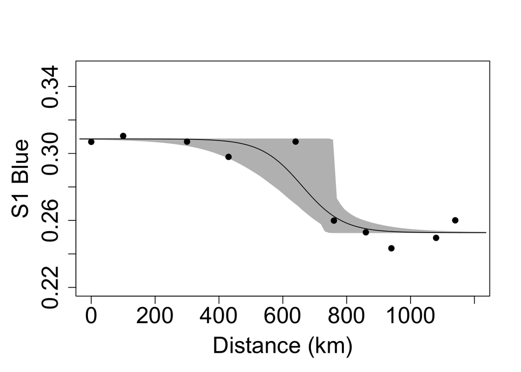

```r
## Plot the 95% credible cline region for the selected model
##hzar.plot.fzCline(mkn$Comp.1$analysis$model.selected);

par(mar=c(5,5,4,2)+.1)
par(ps=22, cex=1, cex.main=1)
male.pc1<-hzar.plot.fzCline(mkn$Comp.1$analysis$model.selected,
                  pch=19,
                  xlab="Distance (km)",
                  ylab="S1 Blue",
                  ylim=c(.22,.35),xlim=c(0,1200))
```

```r
#export as 8"x8" PDF
#dev.off()
## End Comp.1
```